# Analysis of Ordovician and Silurian fossil occurrences as a function of geological context

Peter Smits

22 May, 2019

Step 0 is loading some useful packages for loading and cleaning data.

```r
library(pacman)

p_load(here, janitor, tibble, readr, magrittr, dplyr,
       tidyr, purrr, glue, stringr,
       furrr,
       ggplot2, scales, grid, ggridges, viridis, ggrepel,
       compositions, geosphere,
       arm, rstan, rstanarm, brms,
       devtools)

library(notfossil)
# devtools::load_all()
```

There are several useful constants that will appear throughout the next few sections.

```r
theme_set(theme_bw(base_size = 20))

# colour blind palette of choice
blind <- c("#999999", "#E69F00", "#56B4E9", "#009E73",
           "#F0E442", "#0072B2", "#D55E00", "#CC79A7")

# useful constants
shelly <- c('Brachiopoda', 'Anthozoa', 'Trilobita',
            'Bivalvia', 'Gastropoda')#, 'Cephalopoda')
temp_range <- c(485.4, 419.2)          # ordovicain + silurian
hirnantian <- c(445.2, 443.8)
```

# Scrap data from DBs

We are analyzing the association between fossils and the geological units in which they are found. The data for this analysis is spread across multiple databases, and multiple tables within those databases.

The first major source is Macrostrat, which provides geological information for North America. This information includes unique id-s for fossil collections made from those geological units.

The second major source is the Paleobiology Database, which provides information on those fossil occurrences. Macrostrat and PBDB are linked by a few key variables, most importantly `unit_id` (unique identifer for each geologicla unit.)

In this section, I’m going to pull all of the correct tables from their respective databases and then write them to disk. Which then sets up all of our subsequent analyses. We can regenerate/update our data at anytime by running this script. The only limits are internet connection and server status.

## Macrostrat units

The next step is pulling all of the geological units recorded in Macrostrat for the Ordovician and the Silurian. I’ve had trouble writing out API call to do this all in one step, so I’ve broken it out by period and then combine them.

```r
ord_unit_url <- glue('https://macrostrat.org/api/v2/units?',
                     'interval_name=Ordovician&response=long&format=csv')
ord_unit <- read_csv(ord_unit_url)

sil_unit_url <- glue('https://macrostrat.org/api/v2/units?',
                     'interval_name=Silurian&response=long&format=csv')
sil_unit <- read_csv(sil_unit_url)

unit_data <- dplyr::union(ord_unit, sil_unit) # formerly `strat`

write_csv(unit_data, here::here('data', 'macrostrat_units.csv'))
```

## Macrostrat fossils

Now that we have the data for all of our fossil units, let’s extract the relevant fossil information. `unit_id` is the key value that links the units and fossils tables within the Macrostrat DB.

However, not every unit that has Ordovician or Silurian sediments contains a fossil. A quick filter gives the `unit_id` values for fossil-bearing geological units. This vector can then be massaged and passed to the Macrostrat API.

```r
unit_w_fossils <-
  unit_data %>%
  filter(pbdb_collections > 0) %>%
  dplyr::select(unit_id) %>%
  pull() %>%
  glue_collapse(., sep = ',')

collect_url <- glue('https://macrostrat.org/api/v2/fossils?unit_id=',
                   '{unit_w_fossils}',
                   '&response=long&format=csv')

collect_data <- read_csv(collect_url)  # formerly `fossil`

write_csv(collect_data, here::here('data', 'macrostrat_collect.csv'))
```

## PBDB occurrences

The `collect_data` tibble has all the necessary information to recover fossil occurrence information from the PBDB. The column `cltn_id` has the unique identifier for the PBDB collections assocated with each geological unit (`unit_id`). We can extract and massage the `cltn_id` column into a vector we can pass to the PBDB API, making a call for an occurrence list. The resulting tibble has a row for every fossil occurrence found in collections made from geological units that contain Ordovician or Siliurian sediments.

```r
pbdb_collections <-
  collect_data %>%
  dplyr::select(cltn_id) %>%
  pull() %>%
  glue_collapse(., sep = ',')

pbdb_url <- glue('https://paleobiodb.org/data1.2/occs/list.txt?coll_id=',
                 '{pbdb_collections}',
                 '&show=full')

pbdb_data <- read_csv(pbdb_url) %>%    # formerly `taxon`
  drop_na(genus)
write_csv(pbdb_data, here::here('data', 'pbdb_occurrences.csv'))
```

# Preparing data for analysis

The next step is to process our data so that it is ready for analysis. This process takes a lot of steps, but once it is complete we can start visualizing and modeling out data.

I’ve already prepared some data for this analysis. Check out `00_download_scrap.Rmd` for that (annotated) script.

```r
# formerly `strat`
unit_data <- read_csv(here::here('data', 'macrostrat_units.csv'))

# formerly `fossil`
collect_data <- read_csv(here::here('data', 'macrostrat_collect.csv'))

# formerly `taxon
pbdb_data <- read_csv(here::here('data', 'pbdb_occurrences.csv'))
```

## Joining Macrostrat and PBDB

Now that that’s out of the way, let’s start getting out data into shape. An obvious first step is connect the Macrostrat units table to the fossils table.

There are multiple collections occurrences per unit, so I’ll add all the appropriate unit information to each fossil collection. I’m not worrying about units that lack fossils (yet), hence the left join.

```r
collect_unit <- left_join(x = collect_data, y = unit_data,
                         by = c('unit_id', 'col_id', 't_age', 'b_age')) %>%
  dplyr::select(-(genus_no:taxon_no), refs.y) # redundant/unnecessary

print(collect_unit)
```

```
## # A tibble: 8,693 x 48
##    cltn_id cltn_name t_age b_age pbdb_occs unit_id col_id refs.x
##      <dbl> <chr>     <dbl> <dbl>     <dbl>   <dbl>  <dbl>  <dbl>
##  1     228 SS-24, S…  458.  466.         7    2084     58      8
##  2     237 Marathon…  457.  460.         8    2146     59      8
##  3     244 SW Riche…  480.  502.         5    9412    339      8
##  4     246 SW Riche…  480.  502.        16    9412    339      8
##  5     251 Bear Riv…  483.  496.        17   14482    477      8
##  6     253 Stansbur…  483.  493.         2   14175    471      8
##  7     257 H-1. nea…  483.  494.         6   10248    315      8
##  8     258 SW Riche…  480.  502.        15    9412    339      8
##  9     270 SW Riche…  480.  502.         8    9412    339      8
## 10     271 Zones B …  480.  485.        22    5677    163      8
## # … with 8,683 more rows, and 40 more variables:
## #   strat_name_concept_id <dbl>, section_id <dbl>, project_id <dbl>,
## #   col_area <dbl>, unit_name <chr>, strat_name_id <dbl>, Mbr <chr>,
## #   Fm <chr>, Gp <chr>, SGp <chr>, max_thick <dbl>, min_thick <dbl>,
## #   outcrop <chr>, pbdb_collections <dbl>, pbdb_occurrences <dbl>,
## #   lith <chr>, environ <chr>, econ <chr>, measure <chr>, notes <chr>,
## #   color <chr>, text_color <chr>, t_int_id <dbl>, t_int_name <chr>,
## #   t_int_age <dbl>, t_prop <dbl>, units_above <chr>, b_int_id <dbl>,
## #   b_int_name <chr>, b_int_age <dbl>, b_prop <dbl>, units_below <dbl>,
## #   strat_name_long <chr>, refs.y <chr>, clat <dbl>, clng <dbl>,
## #   t_plat <dbl>, t_plng <dbl>, b_plat <dbl>, b_plng <dbl>
```

This gives a single table with all fossil collections associated with their geological information (lithology, age, etc.) The next step is associating the geological context of each collection with the individual occurrences within that collection. I’m only caring about occurrences recorded in the PBDB – they have the most information – hence the left join. I’m also going to filter the occurrences to just those of shelly marine taxa which I defined above as one of the useful constants.

```r
occur_collect <-
  pbdb_data %>%
  filter(phylum %in% shelly | class %in% shelly) %>%
  left_join(., collect_unit, by = c('collection_no' = 'cltn_id')) %>%
  mutate(occur_mid_ma = (max_ma + min_ma) / 2,
         unit_mid_ma = (t_age + b_age) / 2)
```

## Filter by occurrence age

A big issue is that these occurrences from all over time, not just the Ordovician + Silurian. Just look.

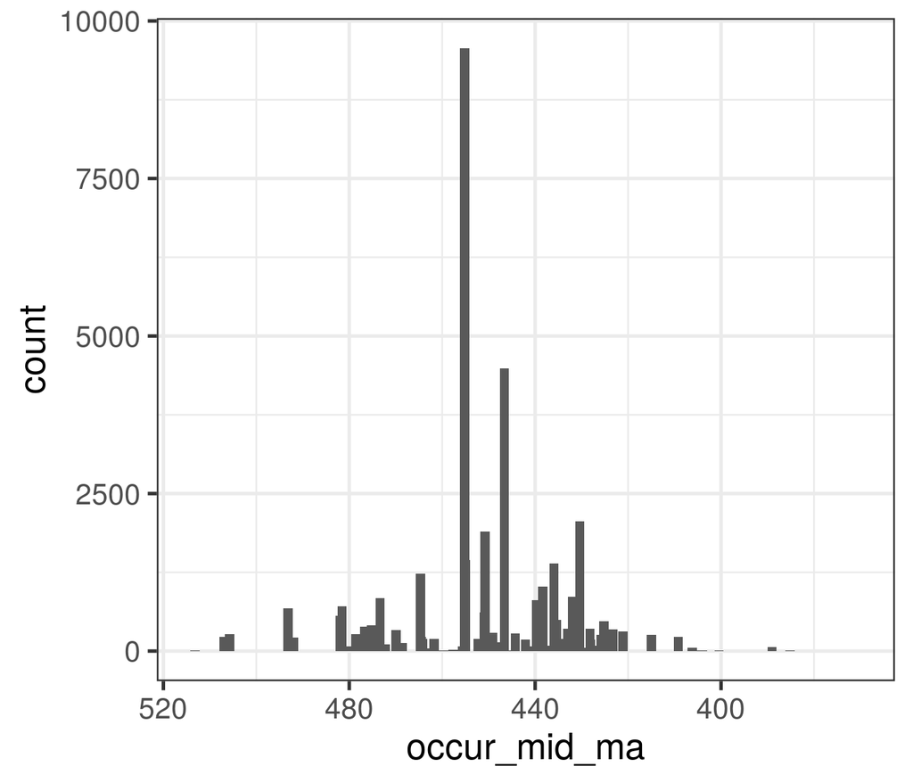

```r
occur_collect %>%
  ggplot(aes(x = occur_mid_ma)) +
  geom_bar(width = 2) +
  scale_x_reverse()
```

This problem due to geological units not being restricted to a particular time interval. A unit can range through, into, or out of our target temporal range.

To overcome this and focus only on fossil occurrences from the Ordovician or Silurian, I filtering down to only those occurrences who’s mid-point age is within `temp_range`.

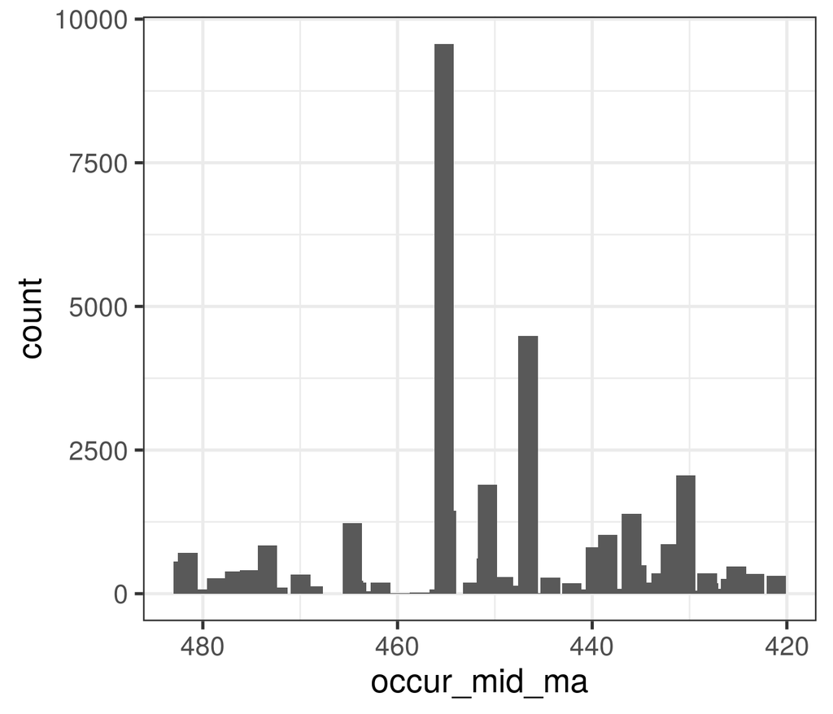

```r
occur_collect %<>%
  filter(between(occur_mid_ma, temp_range[2], temp_range[1]))

occur_collect %>%
  ggplot(aes(x = occur_mid_ma)) +
  geom_bar(width = 2) +
  scale_x_reverse()
```

Much better.

## Binning occurrences

The fossil record is a discrete recording of continuous time which creates all kinds of problems. Additionally, paleo-time is more of a range than an instaneous value. Binning out data helps alleviate this – it just requires us to define a temporal width for each bin. There are two ways to do this: predetermine how many bins you want, or pick an (arbitrary) value. Luckily I’ve written a function that can do both: `bin_ages()`.

I want to compare multiple arbitrary bin widths to pick whatever feels “smoothest”. Sadly, I have trouble defining this algorithmically, but the general idea is to have as many bins as possible to have 1+ fossils and there are as few bins as possible with 0 fossils. Common bin widths include 1, 2, 5, and 10 million years, but I’m gonna look at a few more.

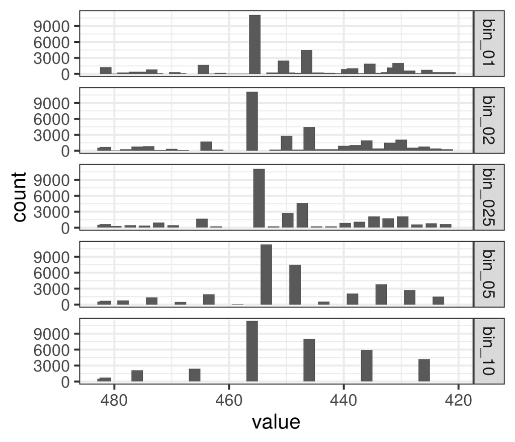

```r
occur_collect %>%
  transmute(bin_01 = bin_ages(occur_mid_ma, by = 1, age = TRUE),
            bin_02 = bin_ages(occur_mid_ma, by = 2, age = TRUE),
            bin_025 = bin_ages(occur_mid_ma, by = 2.5, age = TRUE),
            bin_05 = bin_ages(occur_mid_ma, by = 5, age = TRUE),
            bin_10 = bin_ages(occur_mid_ma, by = 10, age = TRUE)) %>%
  gather(key = key, value = value) %>%
  ggplot(aes(x = value)) +
  geom_bar(width = 2) +
  facet_grid(key ~ .) +
  scale_x_reverse()
```

2 and 2.5 seem like the nicest of these options, and I like to favor having a lot of bins over having few bins so I’m going to stick with 2 million year bins.

### Saving the Hirnantian

However, there is a twist – we’re *really* interested in the occurrence patterns during the Hirnantian. This means I’d like the Hirnantian time interval preserved. The Hirnantian lasted from 445.2 to 443.8 Ma – a *really* small interval of time.

A solution is to bin all the data *before* and *after* the Hirnantian as per usual, leaving the Hirnantian as a one-off. Here is that effort.

```r
occur_before <-
  occur_collect %>%
  filter(occur_mid_ma > max(hirnantian)) %>%
  mutate(bin_age = bin_ages(occur_mid_ma, by = 2, age = TRUE)) %>%
  dplyr::select(occurrence_no, bin_age)

occur_after <-
  occur_collect %>%
  filter(occur_mid_ma < min(hirnantian)) %>%
  mutate(bin_age = bin_ages(occur_mid_ma, by = 2, age = TRUE)) %>%
  dplyr::select(occurrence_no, bin_age)


occur_collect %<>%
  left_join(., occur_before, by = 'occurrence_no') %>%
  left_join(., occur_after, by = 'occurrence_no') %>%
  mutate(bin_age = coalesce(bin_age.x, bin_age.y),
         bin_age = if_else(is.na(bin_age),
                           true = 445.2,
                           false = bin_age),
         # worst trick in the book
         # lower values, younger bin
         bin_num = as.numeric(as.factor(bin_age))) %>%
  dplyr::select(-bin_age.x, -bin_age.y)

write_csv(occur_collect, here::here('data', 'occurrences_clean.csv'))
```

Now are tibble `occur_collect` has every observation assigned to a temporal bin and we know one of these bins (i.e. 445.2) is the Hirnantian. I’ve saved this to disk so it can be shared/interrogated on its own.

# Explore data

Now that’s I’ve cleaned up the data a bunch, I’m going to explore some of the patterns in the data. I’m interested in how occurrence changes over time, when multiple last occurrences are in the same time bin, and geological unit lithological composition.

```r
occur_collect <- read_csv(here::here('data', 'occurrences_clean.csv'))
```

## Shelly occurrences

The shelly groups are a mixture of phyla and classes. I want a single vector with the shelly identity of every observation.

```r
occur_collect %<>%
  mutate(phylum_shelly = ifelse(phylum %in% shelly, phylum, NA),
         class_shelly = ifelse(class %in% shelly, class, NA),
         shelly = coalesce(phylum_shelly, class_shelly))
```

With this information I can plot occurrences over time, highlighted by their shelly type.

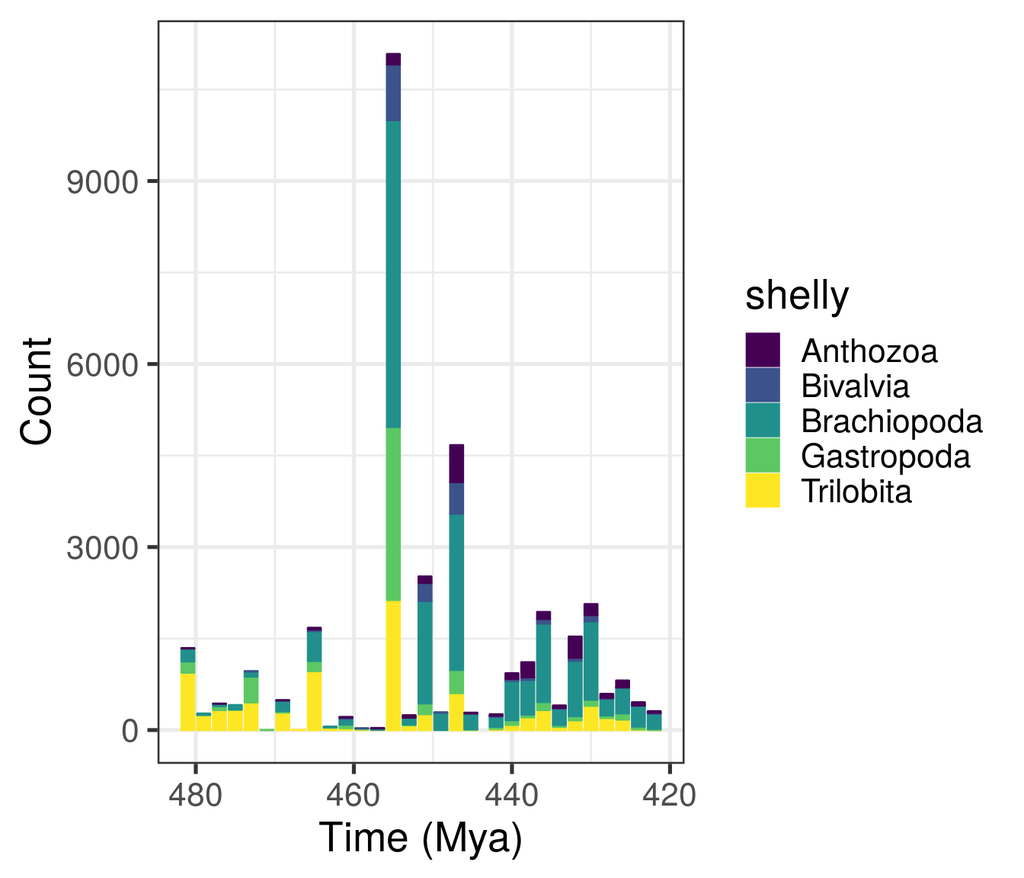

```r
occur_collect %>%
  group_by(shelly, bin_age) %>%
  count() %>%
  ggplot(aes(x = bin_age, y = n,
             colour = shelly, fill = shelly)) +
  geom_col() +
  scale_fill_viridis(discrete = TRUE) +
  scale_color_viridis(discrete = TRUE) +
  scale_x_reverse() +
  labs(x = 'Time (Mya)', y = 'Count')
```

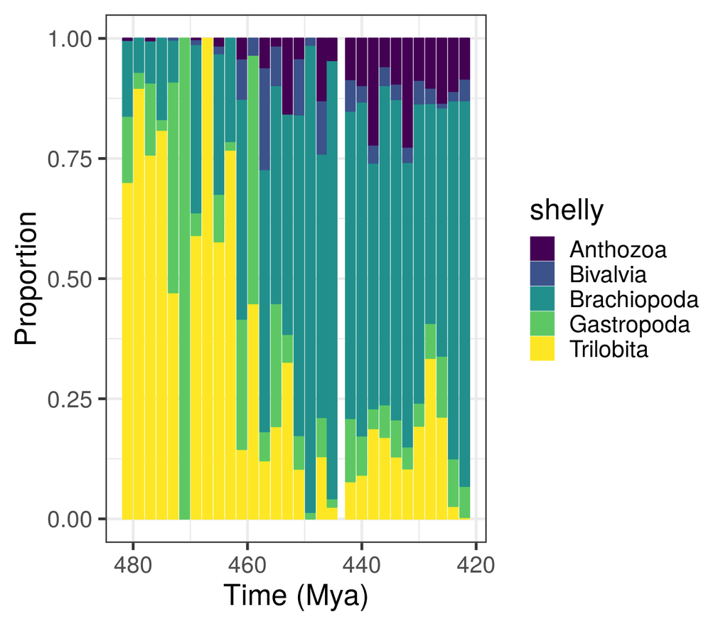

```r
occur_collect %>%
  group_by(shelly, bin_age) %>%
  count() %>%
  ggplot(aes(x = bin_age, y = n,
             colour = shelly, fill = shelly)) +
  geom_col(position = 'fill') +
  scale_fill_viridis(discrete = TRUE) +
  scale_color_viridis(discrete = TRUE) +
  scale_x_reverse() +
  labs(x = 'Time (Mya)', y = 'Proportion')
```

The oldest intervals in our dataset are mostly trilobites, while younger in the series there are more brachiopods. There are some intervals that are absolutely dominated by individual groups.Additionally, corals become more present in younger intervals.

However, here’s the catch – the above plots are for all occurrences in the sense of abundance, and not unique taxonomic occurrences. Here’s a redo of the above that focuses only on unique taxon occurrences. I’m going to filter to genus because that’s such a thing in paleo.

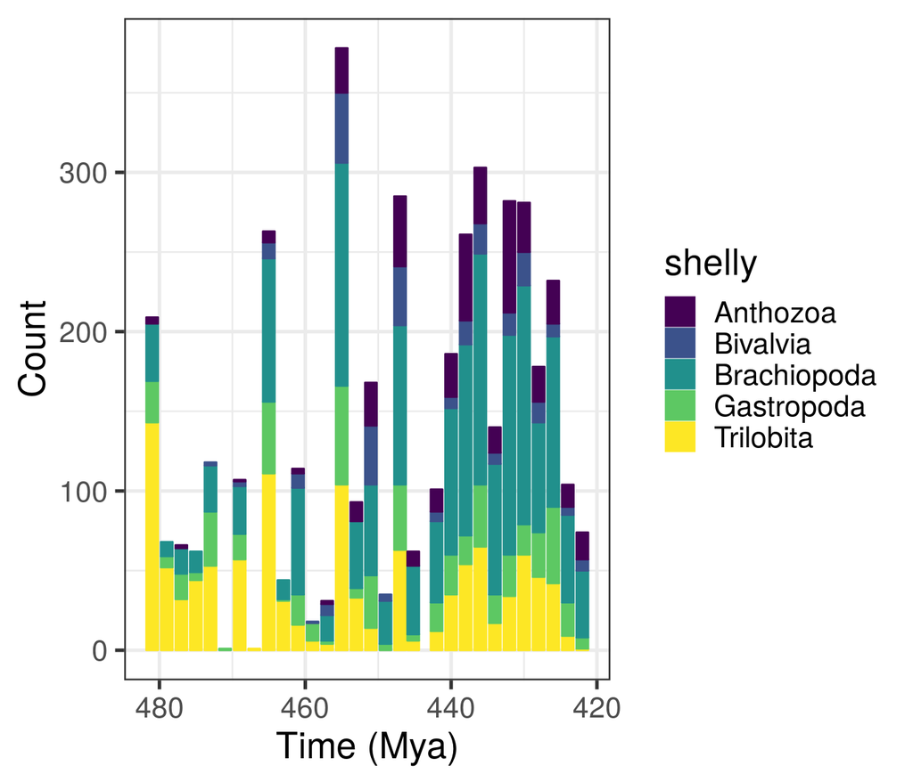

```r
occur_collect %>%
  group_by(shelly, bin_age) %>%
  filter(!duplicated(genus)) %>%
  count() %>%
  ggplot(aes(x = bin_age, y = n,
             colour = shelly, fill = shelly)) +
  geom_col() +
  scale_fill_viridis(discrete = TRUE) +
  scale_color_viridis(discrete = TRUE) +
  scale_x_reverse() +
  labs(x = 'Time (Mya)', y = 'Count')
```

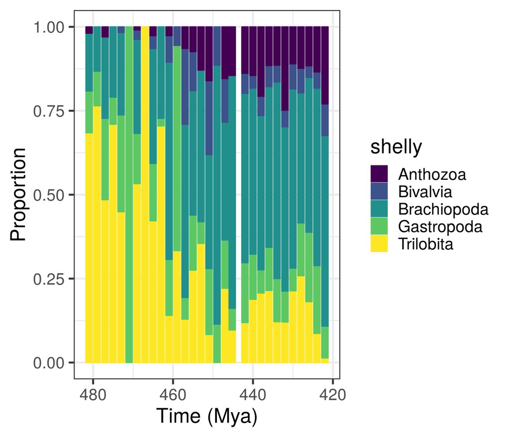

```r
occur_collect %>%
  group_by(shelly, bin_age) %>%
  filter(!duplicated(genus)) %>%
  count() %>%
  ggplot(aes(x = bin_age, y = n,
             colour = shelly, fill = shelly)) +
  geom_col(position = 'fill') +
  scale_fill_viridis(discrete = TRUE) +
  scale_color_viridis(discrete = TRUE) +
  scale_x_reverse() +
  labs(x = 'Time (Mya)', y = 'Proportion')
```

Mostly the same story as before, but some of the patterns we observed earlier are no longer as extreme. Makes sense because we’re moving from abundance to incidence.

## Last occurrences

When is the last time each genus occurs in our dataset? Group the tibble by genus and the calculate the *minimum* time bin. Minimum because time bin age *decreases* as we approach the present.

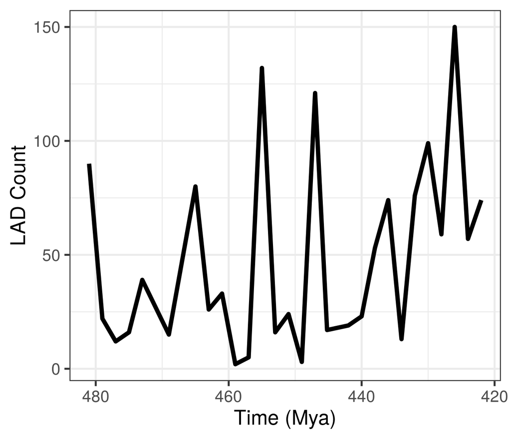

```r
lad <-
  occur_collect %>%
  group_by(shelly, bin_age) %>%
  filter(!duplicated(genus)) %>%
  ungroup() %>%
  group_by(genus) %>%
  dplyr::summarize(lad = min(bin_age)) %>%
  group_by(lad) %>%
  count() %>%
  ungroup() %>%
  arrange(desc(lad)) %>%
  mutate(n_cum = cumsum(n))

lad %>%
  ggplot(aes(x = lad, y = n)) +
  geom_line(size = 2) +
  scale_x_reverse() +
  labs(x = 'Time (Mya)', y = 'LAD Count')
```

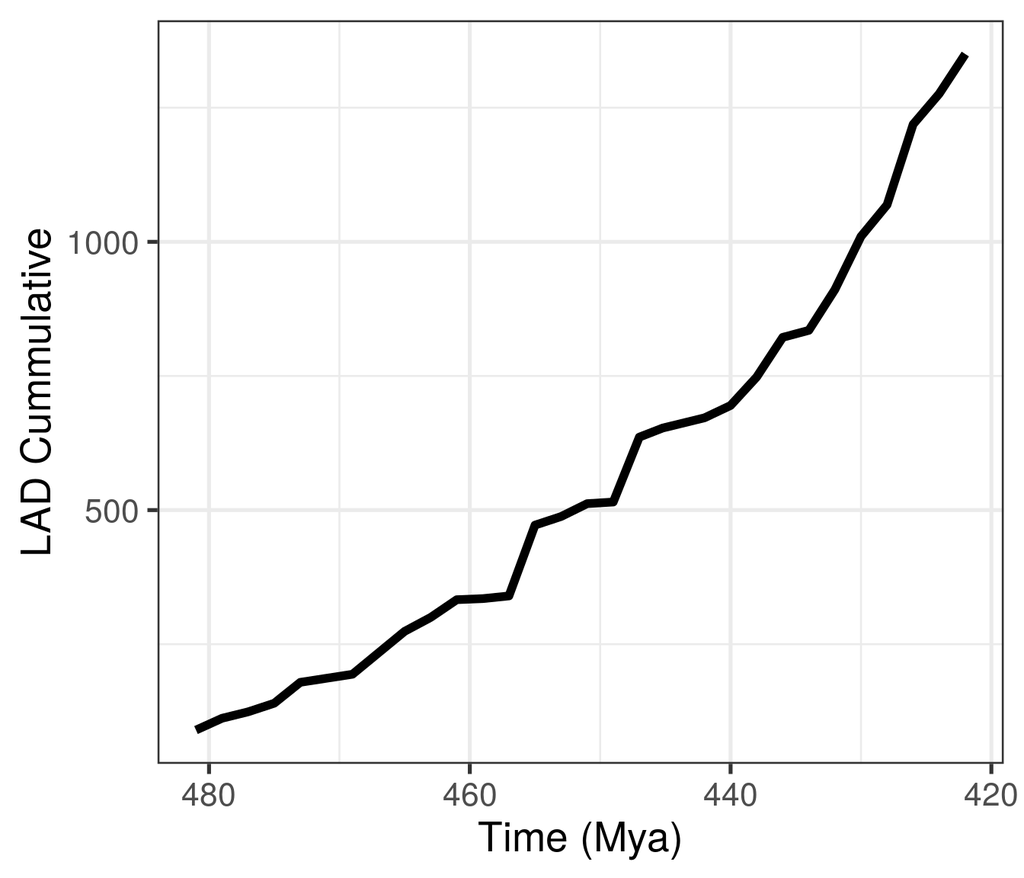

```r
lad %>%
  ggplot(aes(x = lad, y = n_cum)) +
  geom_line(size = 2) +
  scale_x_reverse() +
  labs(x = 'Time (Mya)', y = 'LAD Cummulative')
```

And again by shelly group.

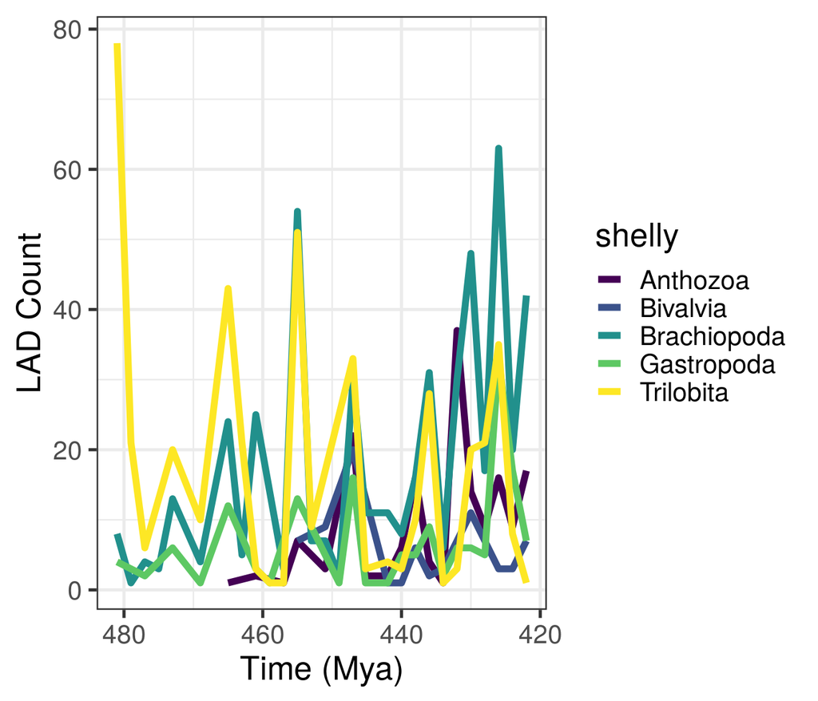

```r
lad_shelly <-
  occur_collect %>%
  group_by(shelly, bin_age) %>%
  filter(!duplicated(genus)) %>%
  ungroup() %>%
  group_by(genus, shelly) %>%
  dplyr::summarize(lad = min(bin_age)) %>%
  group_by(shelly) %>%
  ungroup() %>%
  group_by(shelly, lad) %>%
  count() %>%
  ungroup() %>%
  group_by(shelly) %>%
  arrange(desc(lad)) %>%
  mutate(n_cum = cumsum(n)) %>%
  ungroup()

lad_shelly %>%
  ggplot(aes(x = lad, y = n, colour = shelly)) +
  geom_line(size = 2) +
  scale_colour_viridis(discrete = TRUE) +
  scale_x_reverse() +
  labs(x = 'Time (Mya)', y = 'LAD Count')
```

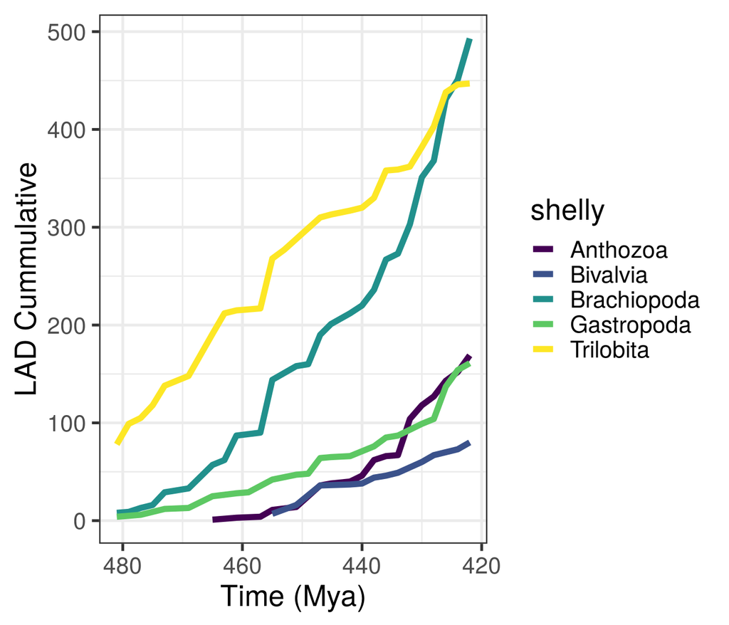

```r
lad_shelly %>%
  ggplot(aes(x = lad, y = n_cum, colour = shelly)) +
  geom_line(size = 2) +
  scale_colour_viridis(discrete = TRUE) +
  scale_x_reverse() +
  labs(x = 'Time (Mya)', y = 'LAD Cummulative')
```

While not the largest spike, all of the shelly groups have spikes in number of LADs at the Hirnantian. How do we interptet this in light of our very biased occurrence record?

## Lithology

For each geological unit there is a short lithological description. Each lithological desciption can have multiple parts which are given a percent of total composition. Here is an example:

```r
occur_collect$lith[1]
```

```
## [1] "shale siliciclastic sedimentary  ~ 0.3333| sandstone siliciclastic sedimentary  ~ 0.3333| limestone carbonate sedimentary  ~ 0.3333"
```

In this example, the lithology of this unit is made up of three major forms with each being approximately one-third of that units composition. Lucky for me, these descriptions have a very regular form which makes extracting important text information surprisingly easy.

There are a lot of potential issues when processing lithological descriptions. For example:

- lots of words that appear only once
- similar word but different part of speech
- descriptions are identical except for small modified (“black shale siliciclastic” vs “red shale siliciclastic”)

All of these problems mean I have to simplify these descriptions.

A basic way of dividing lithologies are by siliciclsatic vs carbonate. Unfortunately, this comparison is not truly binary as mixed-sediments are possible. Additionally, I might be able to extract better information that just “siliciclastic” from our descriptions. With this in mind, I’ve written a function to simplify lithological descriptions to be more amenable to analysis. My goal is to divide the litholgies into “coarse siliciclastic,” “fine siliciclastic,” “carbonate,” and “other.”

```r
p_load(profvis)
lith <- occur_collect$lith


# lithologies are now a list-column
occur_collect %<>%
  mutate(lith_simple = simplify_lithology(lith)) %>%
  unnest() %>%
  mutate(carbonate = replace_na(carbonate, replace = 0),
         coarse_siliciclastic = replace_na(coarse_siliciclastic, replace = 0),
         fine_siliciclastic = replace_na(fine_siliciclastic, replace = 0),
         other = replace_na(other, replace = 0)) %>%
  nest(carbonate, coarse_siliciclastic, fine_siliciclastic, other,
       .key = 'lith_simple')
```

I’ve created a column vector `lith_simple` where each element is a tibble describing the lithologycal composition of that unit in a simpler form. Most of the tricks above are just to make it so each unit has all four lithological descriptors and that there are 0s instead of NAs when that descriptor wasn’t measured.

Now that that data is all in order, we can start exploring that space. Does the average lithological composition of a geologic unit change over time? If so, how?

I’m making the lithological data into a [Atchinson composition](https://rdrr.io/cran/compositions/man/acomp.html) object of the data. This object type has convenient properties for interfacing with the `compositions` package. Once this is done, there are a lot of ways to try and summarize this data. From a math perspective, all the 0s in are dataset cause a lot of problems, but hopefully we’ll be able to skirt those for now.

First, I’m going to calculate mean lithology for the entire sample. Then I’m going to calculate mean lithology for each of the time bins we’ve defined.

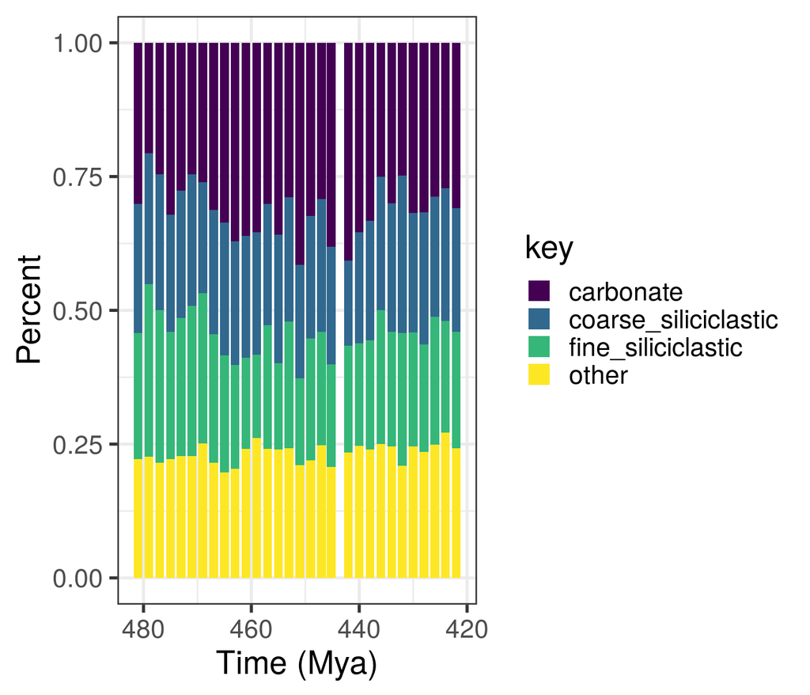

```r
# divide units up by bin
# then get mean lithology
bin_lith <-
  occur_collect %>%
  arrange(desc(bin_age)) %>%
  group_by(bin_age) %>%
  filter(!duplicated(unit_id)) %>%     # no multi-counting
  ungroup() %>%
  group_by(bin_age) %>%
  group_map(~ .x %>%
              dplyr::select(lith_simple) %>%
              unnest() %>%
              acomp() %>%
              mean())

# what age is each value from?
bin_ages_match <-
  occur_collect %>%
  arrange(desc(bin_age)) %>%
  group_by(bin_age) %>%
  filter(!duplicated(unit_id)) %>%     # again, no multi-counting
  ungroup() %>%
  dplyr::select(bin_age) %>%
  pull() %>%
  unique()

lith_time <-
  reduce(bin_lith, rbind) %>%
  as_tibble() %>%
  mutate(bin_age = bin_ages_match) %>%
  gather(key = key, value = value, -bin_age)

lith_time %>%
  ggplot(aes(x = bin_age, y = value, fill = key)) +
  geom_col(size = 1.5) +
  scale_fill_viridis(discrete = TRUE) +
  scale_colour_viridis(discrete = TRUE) +
  scale_x_reverse() +
  labs(x = 'Time (Mya)', y = 'Percent')
```

There do not appear to be any massive shifts in mean composition from time bin to time bin. Remember, some units span multiple bins – we’ve divided units by occurrences. We can also have point size vary by the diversity – the number of unique genera in that unit at that time.

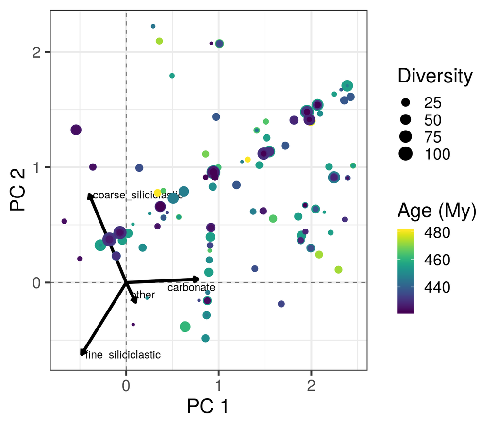

```r
lith_data <-
  occur_collect %>%
  arrange(desc(bin_age)) %>%
  group_by(bin_age) %>%
  filter(!duplicated(unit_id)) %>%     # no multi-counting
  ungroup() %>%
  dplyr::select(lith_simple) %>%
  unnest() %>%
  acomp()

lith_pca <- princomp(lith_data)

# ggfortify doesn't support princomp.acomp output
# have to assemble plot by hand

# get age and diversity labels
lith_labels <-
  occur_collect %>%
  arrange(desc(bin_age)) %>%
  group_by(bin_age, unit_id) %>%
  mutate(div = n_distinct(genus)) %>%
  ungroup() %>%
  group_by(bin_age) %>%
  filter(!duplicated(unit_id)) %>%     # no multi-counting
  ungroup() %>%
  dplyr::select(div, bin_age)


# get loadings to add to plot
lith_load <-
  data.frame(lith_pca$loadings[1:4, 1:3]) %>%
  rownames_to_column() %>%
  as_tibble() %>%
  clean_names() %>%
  mutate(origin = 0)

# make the plot
as_tibble(lith_pca$scores) %>%
  clean_names() %>%
  mutate(age = lith_labels$bin_age,
         div = lith_labels$div) %>%
  ggplot() +
  geom_vline(xintercept = 0, linetype = 'dashed', alpha = 0.5) +
  geom_hline(yintercept = 0, linetype = 'dashed', alpha = 0.5) +
  geom_segment(data = lith_load,
               mapping = aes(x = origin, y = origin,
                             xend = comp_1,
                             yend = comp_2),
               arrow = arrow(length = unit(0.2, 'cm')),
               size = 1.5) +
  geom_text_repel(data = lith_load,
                  mapping = aes(x = comp_1, y = comp_2, label = rowname)) +
  geom_point(mapping = aes(x = comp_1, y = comp_2, colour = age, size = div)) +
  scale_colour_viridis() +
  labs(colour = 'Age (My)',
       size = 'Diversity',
       x = 'PC 1',
       y = 'PC 2')
```

There doesn’t appear to be a lot of obvious temporal or diversity pattern for the data.

There are some other ways of looking at our PCA results. For example, we can look at the compositions implied by the loadings of the components (and its inverse). We can also look at the relative loadings of the components for each principle component on the respective ratios, both “up and down.” The up si the loading, while the down in the inverse loading.

```r
## compositions that represent a perturbation with the vectors represented by the loadings of each of the factors
#plot(lith_pca, type = 'loadings', scale.sdev = 1)
#
## compositions that represent a perturbation with the inverse of the vectors represented by the loadings of each of the factors
#plot(lith_pca, type = 'loadings', scale.sdev = -1)
#
## relative loadings
#plot(lith_pca, type = 'relative')
```